# **Binary Kinship Classification Notebook**

## Installing Correct Dependecies

Need to use Tensorflow 1.14 and Keras 2.2.4 for VGGFace

```python
!pip install 'h5py<3.0.0'
```

```
     |████████████████████████████████| 2.9 MB 5.4 MB/s
  Attempting uninstall: h5py
    Found existing installation: h5py 3.1.0
    Uninstalling h5py-3.1.0:
      Successfully uninstalled h5py-3.1.0
```

```python
%tensorflow_version 2.x
!pip uninstall -y tensorflow
!pip install tensorflow-gpu==1.14.0
```

[output not shown]

```python
!pip install q keras==2.2.4
```

```
     |████████████████████████████████| 312 kB 5.3 MB/s
  Attempting uninstall: keras
    Found existing installation: keras 2.7.0
    Uninstalling keras-2.7.0:
      Successfully uninstalled keras-2.7.0
```

```python
from tensorflow.python import keras
print(keras.__version__)
```

```
2.2.4-tf
```

```python
import tensorflow as tf
print(tf.__version__)
```

```
1.14.0
```

Making sure we are using Colab's GPU

```python
tf.test.gpu_device_name()
```

```
'/device:GPU:0'
```

## Importing Data from GDrive into Colab Directory

```python
from google.colab import drive
drive.mount('/content/gdrive')
```

### Unzipping original Families in the Wild (FITW) Dataset

```python
!unzip "/content/gdrive/MyDrive/Kinship_Data/train-faces.zip" -d "/content/Kinship"
```

[output not shown]

[output cut: 4946 more lines]

[output not shown]

### Unzipping FITW Dataset after running through MTCNN

```python
!unzip "/content/gdrive/MyDrive/Kinship_Data/train-new-faces.zip" -d "/content/Kinship"
```

[output not shown]

[output cut: 4946 more lines]

[output not shown]

### Unzipping FITW dataset after images were randomly rotated

```python
!unzip "/content/gdrive/MyDrive/Kinship_Data/train-rotated-faces.zip" -d "/content/Kinship"
```

[output not shown]

[output cut: 4946 more lines]

[output not shown]

Copying FITW CSV file into Colab directory

```python
!cp "/content/gdrive/MyDrive/Kinship_Data/train-pairs.csv" "/content/Kinship"
```

## Importing Libraries

```python
import warnings
warnings.filterwarnings('ignore')
```

```python
import h5py
from collections import defaultdict
from glob import glob
from random import choice,sample
import cv2
import numpy as np
import pandas as pd
import matplotlib.pyplot as plt
import matplotlib.image as mpimg
import os
```

Importing VggFace

```python
!pip install git+https://github.com/rcmalli/keras-vggface.git
```

```
  Cloning https://github.com/rcmalli/keras-vggface.git to /tmp/pip-req-build-rucq40z1
  Running command git clone -q https://github.com/rcmalli/keras-vggface.git /tmp/pip-req-build-rucq40z1
```

```python
from keras.callbacks import ModelCheckpoint,ReduceLROnPlateau,EarlyStopping
from keras.layers import Input,Dense,GlobalMaxPool2D,GlobalAvgPool2D,Concatenate,Multiply,Dropout,Subtract,Lambda
from keras.models import Model
from keras.optimizers import Adam
from keras_vggface.utils import preprocess_input
from keras_vggface.vggface import VGGFace
from keras import backend as K
from keras.models import load_model
```

## Data Pre-Processing

Function to compare before and after image pre-processing

```python
def show_b_and_a(path1, path2):
  before = mpimg.imread(path1)
  after = mpimg.imread(path2)

  f = plt.figure()
  f.add_subplot(1,4, 1)
  plt.title(path1.split('/', 4)[4])
  plt.xlabel("Before")
  plt.imshow(before)
  f.add_subplot(1,4, 4)
  plt.title(path2.split('/', 4)[4])
  plt.xlabel("After MTCNN")
  plt.imshow(after)
  plt.show(block=True)
```

We first used a MTCNN on every image in the FITW dataset in order for our model to focus on the faces of each image

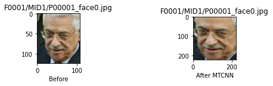

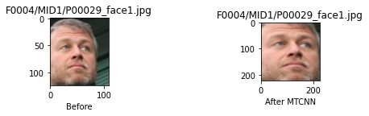

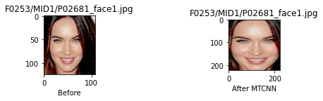

```python
show_b_and_a("/content/Kinship/train-faces/F0001/MID1/P00001_face0.jpg", "/content/Kinship/train-new-faces/F0001/MID1/P00001_face0.jpg")
show_b_and_a("/content/Kinship/train-faces/F0004/MID1/P00029_face1.jpg", "/content/Kinship/train-new-faces/F0004/MID1/P00029_face1.jpg")
show_b_and_a("/content/Kinship/train-faces/F0253/MID1/P02681_face1.jpg", "/content/Kinship/train-new-faces/F0253/MID1/P02681_face1.jpg")
```

We then rotate those images randomly and add that to our dataset, which in turn doubles our dataset

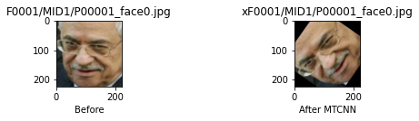

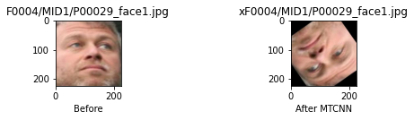

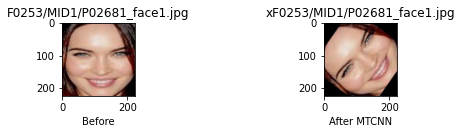

```python
show_b_and_a("/content/Kinship/train-new-faces/F0001/MID1/P00001_face0.jpg", "/content/Kinship/train-rotated-faces/xF0001/MID1/P00001_face0.jpg")
show_b_and_a("/content/Kinship/train-new-faces/F0004/MID1/P00029_face1.jpg", "/content/Kinship/train-rotated-faces/xF0004/MID1/P00029_face1.jpg")
show_b_and_a("/content/Kinship/train-new-faces/F0253/MID1/P02681_face1.jpg", "/content/Kinship/train-rotated-faces/xF0253/MID1/P02681_face1.jpg")
```

## Data Processing & Visualization

### File Pathing

Getting the file paths of all our data

```python
train_file_path='/content/Kinship/train-pairs.csv'
train_folders_path='/content/Kinship/train-new-faces/'
train_rotated_folders_path = '/content/Kinship/train-rotated-faces/'
val_families='F08' # We use families with a label starting with F08 as our validation data
test_families='F09' # We use families with a label starting with F09 as our test data
```

Training, Validation, and Test splits of all the images

```python
all_images=glob(train_folders_path + '*/*/*.jpg') # gets paths of all images
all_images += glob(train_rotated_folders_path + '*/*/*.jpg') # adding rotated images into our dataset

train_images=[x for x in all_images if val_families not in x and test_families not in x]
val_images=[x for x in all_images if val_families in x]
test_images=[x for x in all_images if test_families in x]
```

Gets the local path of each person

```python
ppl=[x.split('/')[-3]+'/'+x.split("/")[-2] for x in all_images]
print(ppl[:5])
```

```
['F0432/MID6', 'F0432/MID6', 'F0432/MID6', 'F0432/MID1', 'F0432/MID1']
```

### Statistics of our Dataset

```python
families = sorted(os.listdir(train_folders_path))
print('We have {} families in the dataset'.format(len(families)))
```

```
We have 571 families in the dataset
```

```python
print("Number of total images in the dataset: ", len(all_images))
print("Number of images used for training: ", len(train_images))
print("Number of images used for validation: ", len(val_images))
print("number of images used for testing: ", len(test_images))
```

```
Number of total images in the dataset:  43840
Number of images used for training:  35018
Number of images used for validation:  3816
number of images used for testing:  5006
```

### Data Processing

Creating a dictionary to map people to their faces

```python
train_person_to_images_map=defaultdict(list)
for x in train_images:
  train_person_to_images_map[x.split('/')[-3]+'/'+x.split("/")[-2]].append(x)

val_person_to_images_map=defaultdict(list)
for x in val_images:
  val_person_to_images_map[x.split('/')[-3]+'/'+x.split('/')[-2]].append(x)

test_person_to_images_map=defaultdict(list)
for x in test_images:
  test_person_to_images_map[x.split('/')[-3]+'/'+x.split('/')[-2]].append(x)
```

Obtaining relationship pairs and converting them to tuples

```python
relationships = pd.read_csv(train_file_path)
relationships = list(zip(relationships.p1.values, relationships.p2.values))

relationships = [x for x in relationships if x[0] in ppl and x[1] in ppl] # Relationships of data in train-new-faces
relationships2 = [('x'+x[0],'x'+x[1]) for x in relationships if 'x' + x[0] in ppl and 'x' + x[1] in ppl] # Relationships of rotated data
relationships += relationships2
```

### Relationship Visualization

Looking at the first 10 relationships from csv file

```python
def load_img(PATH): return np.array(Image.open(PATH))

def plots(ims, figsize=(12,6), rows=1, titles=None):
    f = plt.figure(figsize=figsize)
    for i in range(len(ims)):
        sp = f.add_subplot(rows, len(ims)//rows, i+1)
        sp.axis('Off')
        if titles is not None: sp.set_title(titles[i], fontsize=16)
        plt.imshow(ims[i])
```

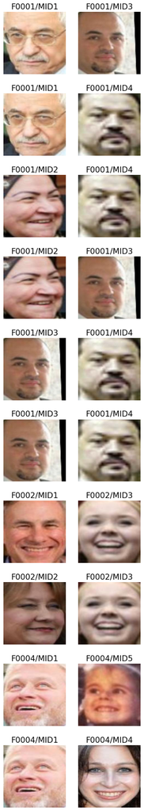

```python
from PIL import Image
def plot_relations(df, BASE='/content/Kinship/train-new-faces/', rows=1, titles=None):
    tdf = df[:rows]
    tdf1 = tdf.p1
    tdf2 = tdf.p2
    figsize=(5,3*rows)
    f = plt.figure(figsize=figsize)
    x = 0
    for i in range(rows):
        sp = f.add_subplot(rows, 2, x+1)
        sp.axis('Off')
        x+=1
        image_path = os.path.join(BASE,tdf1[i])
        im = os.listdir(image_path)[-1]
        sp.set_title(tdf1[i], fontsize=16)
        plt.imshow(load_img(os.path.join(image_path, im)))
        sp = f.add_subplot(rows, 2, x+1)
        x+=1
        sp.axis('Off')
        image_path = os.path.join(BASE,tdf2[i])
        im = os.listdir(image_path)[-1]
        sp.set_title(tdf2[i], fontsize=16)
        plt.imshow(load_img(os.path.join(image_path, im)))

plot_relations(pd.read_csv(train_file_path), rows=10)
```

### Preparing data for Model Training

Train and Validation split of relationships

```python
train=[x for x in relationships if val_families not in x[0] and test_families not in x[0]]
val=[x for x in relationships if val_families in x[0]]
test=[x for x in relationships if test_families in x[0]]
```

Function to correctly resize image input to put into VGGFace model

```python
def read_img_vgg(path):
    img = cv2.imread(path)
    img = cv2.resize(img,(224,224))
    img = np.array(img).astype(np.float)
    return preprocess_input(img, version=2)
```

Function generates data in batches to put into model while also creating labels for the model to train on

```python
def data_generator(list_tuples,person_to_images_map,batch_size=16):
  ppl=list(person_to_images_map.keys())
  while True:
    batch_tuples=sample(list_tuples,batch_size//2)
    labels=[1]*len(batch_tuples)
    while len(batch_tuples)<batch_size:
      p1=choice(ppl)
      p2=choice(ppl)

      if p1!=p2 and (p1,p2) not in list_tuples and (p2,p1) not in list_tuples:
        batch_tuples.append((p1,p2))
        labels.append(0)
    for x in batch_tuples:
      if not len(person_to_images_map[x[0]]):
        print(x[0])
    X1=[choice(person_to_images_map[x[0]]) for x in batch_tuples]
    X1=np.array([read_img_vgg(x) for x in X1])
    X2=[choice(person_to_images_map[x[1]]) for x in batch_tuples]
    X2=np.array([read_img_vgg(x) for x in X2])

    yield [X1,X2],labels
```

## Model Setup

VGGFace model with a ResNet50 Architecture

```python
def build_model():
  input1=Input(shape=(224,224,3))
  input2=Input(shape=(224,224,3))

  base_model=VGGFace(model='resnet50',include_top=False)

  x1=base_model(input1)
  x2=base_model(input2)

  x1=Concatenate(axis=-1)([GlobalMaxPool2D()(x1),GlobalAvgPool2D()(x1)])
  x2=Concatenate(axis=-1)([GlobalMaxPool2D()(x2),GlobalAvgPool2D()(x2)])

  x3=Subtract()([x1,x2])
  x3=Multiply()([x3,x3])
  #x=Multiply()([x3,x3])

  #x=Multiply()([x1,x2])
  x1_=Multiply()([x1,x1])
  x2_=Multiply()([x2,x2])
  x4=Subtract()([x1_,x2_])

  x5=Multiply()([x1,x2])

  x=Concatenate(axis=-1)([x3,x4,x5])

  x=Dense(100,activation='relu')(x)
  x=Dropout(0.01)(x)
  out=Dense(1,activation='sigmoid')(x)

  model=Model([input1,input2],out)

  model.compile(loss='binary_crossentropy',metrics=['acc'],optimizer=Adam(0.00001))

  model.summary()

  return model
```

File path to save model

```python
file_path='/content/Kinship/vgg_face_madmoud.h5'
```

Implementing checkpoints, learning rate reduction, and early stopping

```python
#Using callbacks
checkpoint=ModelCheckpoint(file_path,monitor='val_acc',verbose=1,save_best_only=True,mode='max') #Saves the best model based on val_acc

reduce_lr_on_plateau=ReduceLROnPlateau(monitor='val_acc',mode='max',factor=0.1,patience=20,verbose=1) #Reduces the learning rate when val_acc is not improving

es = EarlyStopping(monitor='val_loss', mode='min', verbose=1)

callbacks_list=[checkpoint,reduce_lr_on_plateau,es]
```

```python
model=build_model()
```

[output not shown]

[output cut: 26 more lines]

```
__________________________________________________________________________________________________
concatenate_3 (Concatenate)     (None, 12288)        0           multiply_1[0][0]
                                                                 subtract_2[0][0]
                                                                 multiply_4[0][0]
__________________________________________________________________________________________________
dense_1 (Dense)                 (None, 100)          1228900     concatenate_3[0][0]
__________________________________________________________________________________________________
dropout_1 (Dropout)             (None, 100)          0           dense_1[0][0]
__________________________________________________________________________________________________
dense_2 (Dense)                 (None, 1)            101         dropout_1[0][0]
==================================================================================================
Total params: 24,790,153
Trainable params: 24,737,033
Non-trainable params: 53,120
__________________________________________________________________________________________________
```

## Model Training

```python
history=model.fit_generator(data_generator(train,train_person_to_images_map,batch_size=16),\
                    use_multiprocessing=True,\
                    validation_data=data_generator(val, val_person_to_images_map, batch_size=16),\
                    epochs=100,verbose=1,workers=4,callbacks=callbacks_list,steps_per_epoch=200,validation_steps=100)
```

```
Epoch 00001: val_acc improved from -inf to 0.65875, saving model to /content/Kinship/vgg_face_madmoud.h5

Epoch 00002: val_acc improved from 0.65875 to 0.71937, saving model to /content/Kinship/vgg_face_madmoud.h5

Epoch 00003: val_acc improved from 0.71937 to 0.74875, saving model to /content/Kinship/vgg_face_madmoud.h5

Epoch 00004: val_acc improved from 0.74875 to 0.77250, saving model to /content/Kinship/vgg_face_madmoud.h5

Epoch 00005: val_acc improved from 0.77250 to 0.77312, saving model to /content/Kinship/vgg_face_madmoud.h5

Epoch 00006: val_acc improved from 0.77312 to 0.79125, saving model to /content/Kinship/vgg_face_madmoud.h5

Epoch 00007: val_acc improved from 0.79125 to 0.79250, saving model to /content/Kinship/vgg_face_madmoud.h5
Epoch 00007: early stopping
```

Copy saved model into GDrive

```python
!cp  "/content/Kinship/vgg_face_madmoud.h5" "/content/gdrive/MyDrive/"
```

## Visualization of Model Training Data

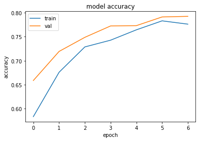

```python
plt.plot(history.history['acc'])
plt.plot(history.history['val_acc'])
plt.title('model accuracy')
plt.ylabel('accuracy')
plt.xlabel('epoch')
plt.legend(['train', 'val'], loc='upper left')
plt.show()
```

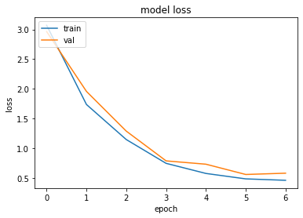

```python
plt.plot(history.history['loss'])
plt.plot(history.history['val_loss'])
plt.title('model loss')
plt.ylabel('loss')
plt.xlabel('epoch')
plt.legend(['train', 'val'], loc='upper left')
plt.show()
```

## Tesing Model

Copying model into Colab from Google Drive (Run only if you just want to load the model and not do any training)

```python
!cp  "/content/gdrive/MyDrive/Kinship_Data/vgg_face_madmoud.h5" "/content/Kinship/"
```

Loading the model from a path

```python
model=load_model('/content/Kinship/vgg_face_madmoud.h5')
```

Creating the labels of the test data

```python
test_len = len(test)
test_labels = [1]*len(test)
```

Generating unrelated people from the test set appending it to the test set and and also appending it to the test labels

```python
ppl=list(test_person_to_images_map.keys())
i = 0
while i < test_len:
  p1 = choice(ppl)
  p2 = choice(ppl)
  if p1!=p2 and (p1,p2) not in test and (p2,p1) not in test:
        test.append((p1,p2))
        test_labels.append(0)
        i += 1
```

Showing two images from the test set and using our model to predict the given unseen images

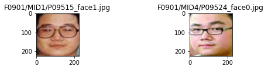

```
Model probablity that there is a Kinship relationship [[0.9999989]]
Actual label of the two images:  1
```

```python
test1_path = choice(test_person_to_images_map.get(test[0][0]))
test2_path = choice(test_person_to_images_map.get(test[0][1]))
testimg1 = mpimg.imread(test1_path)
testimg2 = mpimg.imread(test2_path)

f = plt.figure()
f.add_subplot(1,4, 1)
plt.title(test1_path.split('/', 4)[4])
plt.imshow(testimg1)
f.add_subplot(1,4, 4)
plt.title(test2_path.split('/', 4)[4])
plt.imshow(testimg2)
plt.show(block=True)
X1 = np.array([read_img_vgg(test1_path)])
X2 = np.array([read_img_vgg(test2_path)])
result = model.predict([X1, X2])
print("Model probablity that there is a Kinship relationship", result)
print("Actual label of the two images: ", test_labels[0])
```

Now we run our model against the entire test set

We use a .4 activation on our model which means that if our model probability is greater than .4 we say that there is a relationship between the two images

```python
count = 0
pred = []
for i in range(len(test)):
  X1 = choice(test_person_to_images_map.get(test[i][0]))
  X2 = choice(test_person_to_images_map.get(test[i][1]))
  X1 = np.array([read_img_vgg(X1)])
  X2 = np.array([read_img_vgg(X2)])
  result = model.predict([X1, X2])
  if result >= .4:
    pred.append(1)
    if test_labels[i] == 1:
      count += 1
  else:
    pred.append(0)
    if test_labels[i] == 0:
      count += 1
```

We use a confusion matrix to see the results of our predictions

```python
from sklearn.metrics import confusion_matrix
```

```python
cm = confusion_matrix(test_labels, pred)
```

```python
print("Our accuracy is {}%".format(((cm[0][0] + cm[1][1])/len(test))*100))
```

```
Our accuracy is 78.99284862932062%
```

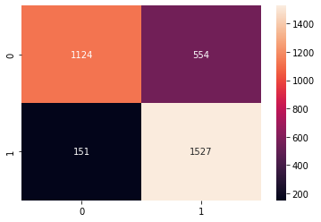

```python
import seaborn as sns
sns.heatmap(cm, annot=True, fmt='g')
```